# Bike Sharing System : Problem Statement

A bike-sharing system is a service in which bikes are made availablem for shared use to individuals on a short term basis for a price or free. Many bike share systems allow people to borrow a bike from a "dock" which is usually computer-controlled wherein the user enters the payment information, and the system unlocks it. This bike can then be returned to another dock belonging to the same system.

A US bike-sharing provider BoomBikes has recently suffered considerable dips in their revenues due to the ongoing Corona pandemic. The company is finding it very difficult to sustain in the current market scenario. So, it has decided to come up with a mindful business plan to be able to accelerate its revenue as soon as the ongoing lockdown comes to an end, and the economy restores to a healthy state.

In such an attempt, BoomBikes aspires to understand the demand for shared bikes among the people after this ongoing quarantine situation ends across the nation due to Covid-19. They have planned this to prepare themselves to cater to the people's needs once the situation gets better all around and stand out from other service providers and make huge profits.

They have contracted a consulting company to understand the factors on which the demand for these shared bikes depends. Specifically, they want to understand the factors affecting the demand for these shared bikes in the American market. The company wants to know:

Which variables are significant in predicting the demand for shared bikes. How well those variables describe the bike demands Based on various meteorological surveys and people's styles, the service provider firm has gathered a large dataset on daily bike demands across the American market based on some factors.

# Load Library

```python
import numpy as np
import pandas as pd
import matplotlib.pyplot as plt
import seaborn as sns
```

```python
%matplotlib inline
```

```python
#ignore warnings
import warnings
warnings.filterwarnings("ignore")
```

# Load Data

```python
data = pd.read_csv("day.csv")
```

```python
#data shape
data.shape
```

```
(730, 16)
```

```python
#data head
data.head()
```

|  | instant | dteday | season | yr | mnth | holiday | weekday | workingday | weathersit | temp | atemp | hum | windspeed | casual | registered | cnt |
| --- | --- | --- | --- | --- | --- | --- | --- | --- | --- | --- | --- | --- | --- | --- | --- | --- |
| 0 | 1 | 01-01-2018 | 1 | 0 | 1 | 0 | 6 | 0 | 2 | 14.110847 | 18.18125 | 80.5833 | 10.749882 | 331 | 654 | 985 |
| 1 | 2 | 02-01-2018 | 1 | 0 | 1 | 0 | 0 | 0 | 2 | 14.902598 | 17.68695 | 69.6087 | 16.652113 | 131 | 670 | 801 |
| 2 | 3 | 03-01-2018 | 1 | 0 | 1 | 0 | 1 | 1 | 1 | 8.050924 | 9.47025 | 43.7273 | 16.636703 | 120 | 1229 | 1349 |
| 3 | 4 | 04-01-2018 | 1 | 0 | 1 | 0 | 2 | 1 | 1 | 8.200000 | 10.60610 | 59.0435 | 10.739832 | 108 | 1454 | 1562 |
| 4 | 5 | 05-01-2018 | 1 | 0 | 1 | 0 | 3 | 1 | 1 | 9.305237 | 11.46350 | 43.6957 | 12.522300 | 82 | 1518 | 1600 |

```python
#data info
data.info()
```

```
<class 'pandas.core.frame.DataFrame'>
RangeIndex: 730 entries, 0 to 729
Data columns (total 16 columns):
 #   Column      Non-Null Count  Dtype
---  ------      --------------  -----
 0   instant     730 non-null    int64
 1   dteday      730 non-null    object
 2   season      730 non-null    int64
 3   yr          730 non-null    int64
 4   mnth        730 non-null    int64
 5   holiday     730 non-null    int64
 6   weekday     730 non-null    int64
 7   workingday  730 non-null    int64
 8   weathersit  730 non-null    int64
 9   temp        730 non-null    float64
 10  atemp       730 non-null    float64
 11  hum         730 non-null    float64
 12  windspeed   730 non-null    float64
 13  casual      730 non-null    int64
 14  registered  730 non-null    int64
 15  cnt         730 non-null    int64
dtypes: float64(4), int64(11), object(1)
memory usage: 91.4+ KB
```

### insights : No Features have blank values

```python
#cross verify : across feature
data.isnull().sum()
```

```
instant       0
dteday        0
season        0
yr            0
mnth          0
holiday       0
weekday       0
workingday    0
weathersit    0
temp          0
atemp         0
hum           0
windspeed     0
casual        0
registered    0
cnt           0
dtype: int64
```

```python
#cross verify : across row
data[data.isnull().sum(axis=1)>0]
```

|  | instant | dteday | season | yr | mnth | holiday | weekday | workingday | weathersit | temp | atemp | hum | windspeed | casual | registered | cnt |
| --- | --- | --- | --- | --- | --- | --- | --- | --- | --- | --- | --- | --- | --- | --- | --- | --- |

# Duplicate Rows & Columns

```python
data[data.duplicated()]
```

|  | instant | dteday | season | yr | mnth | holiday | weekday | workingday | weathersit | temp | atemp | hum | windspeed | casual | registered | cnt |
| --- | --- | --- | --- | --- | --- | --- | --- | --- | --- | --- | --- | --- | --- | --- | --- | --- |

#### insights : no rows have duplicate rows

# Unique Count across Features

```python
data.nunique()
```

```
instant       730
dteday        730
season          4
yr              2
mnth           12
holiday         2
weekday         7
workingday      2
weathersit      3
temp          498
atemp         689
hum           594
windspeed     649
casual        605
registered    678
cnt           695
dtype: int64
```

#### instant & dteday have 730 uniques values which is equal to row count so , it won't contribute to any analysis

```python
data.loc[:,['instant','dteday']].head()
```

|  | instant | dteday |
| --- | --- | --- |
| 0 | 1 | 01-01-2018 |
| 1 | 2 | 02-01-2018 |
| 2 | 3 | 03-01-2018 |
| 3 | 4 | 04-01-2018 |
| 4 | 5 | 05-01-2018 |

```python
#drop instant & dteday
data.drop(['instant','dteday'],axis=1,inplace=True)
```

```python
data.columns
```

```
Index(['season', 'yr', 'mnth', 'holiday', 'weekday', 'workingday',
       'weathersit', 'temp', 'atemp', 'hum', 'windspeed', 'casual',
       'registered', 'cnt'],
      dtype='object')
```

# Casual + Registered = cnt

```python
data.loc[:,['casual','registered', 'cnt']].head()
```

|  | casual | registered | cnt |
| --- | --- | --- | --- |
| 0 | 331 | 654 | 985 |
| 1 | 131 | 670 | 801 |
| 2 | 120 | 1229 | 1349 |
| 3 | 108 | 1454 | 1562 |
| 4 | 82 | 1518 | 1600 |

#### drop casual , registered as we can predict using cnt and target is total impact not based on customer type i.e casual or registered user

```python
casual = data.pop('casual')
```

```python
registered = data.pop('registered')
```

```python
data.columns
```

```
Index(['season', 'yr', 'mnth', 'holiday', 'weekday', 'workingday',
       'weathersit', 'temp', 'atemp', 'hum', 'windspeed', 'cnt'],
      dtype='object')
```

# EDA

### Categorical Variable

```python
data.season = data.season.map({1:"spring", 2:"summer", 3:"fall", 4:"winter"})
```

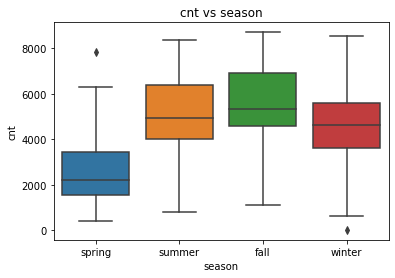

```python
sns.boxplot(data=data,x='season',y='cnt')
plt.title("cnt vs season")
plt.show()
```

#### In summer & fall the cnt is more than winter and that more than spring, so season have some impact on cnt

```python
data.weathersit = data.weathersit.map({1:"Clear", 2:"Mist",3:"Snow",4:"Rain"})
```

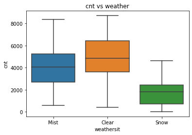

```python
sns.boxplot(data=data,x='weathersit',y='cnt')
plt.title("cnt vs weather")
plt.show()
```

#### snow has smallest count vs clear has the highest cnt

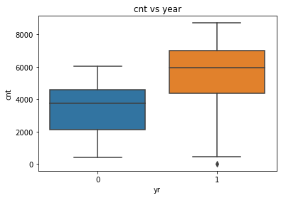

```python
sns.boxplot(data=data,x='yr',y='cnt')
plt.title("cnt vs year")
plt.show()
```

#### in 2019 we have cnt is much more than 2018, so year will have impact on the cnt

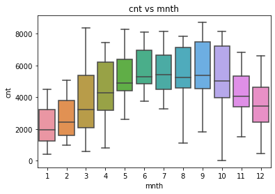

```python
sns.boxplot(data=data,x='mnth',y='cnt')
plt.title("cnt vs mnth")
plt.show()
```

#### in the mid of the year in month of june-oct there is highest cnt vs other mnth

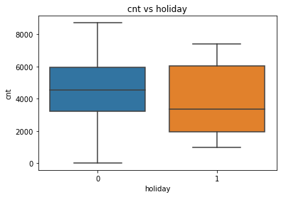

```python
sns.boxplot(data=data,x='holiday',y='cnt')
plt.title("cnt vs holiday")
plt.show()
```

#### In holiday people don't prefer to go for ride, that why cnt is low for value 1

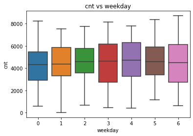

```python
sns.boxplot(data=data,x='weekday',y='cnt')
plt.title("cnt vs weekday")
plt.show()
```

#### weekday does not have much impact on cnt , so may be we can drop this in our model building

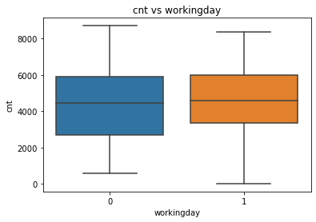

```python
sns.boxplot(data=data,x='workingday',y='cnt')
plt.title("cnt vs workingday")
plt.show()
```

#### working day does not have much impact on the higher side of the cnt , so may be we can drop this in our model building

### Numerical Variable

```python
num_vars=['temp', 'atemp', 'hum', 'windspeed','cnt']
```

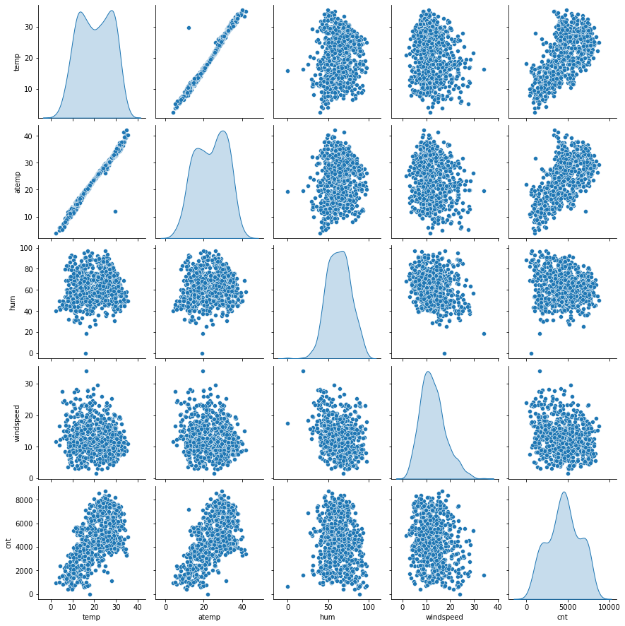

```python
sns.pairplot(data.loc[:,num_vars],diag_kind='kde')
```

#### cnt has some linear relation with temp & atemp , will check it with heatmap as well

#### temp and atemp seems to have high correlation , so may be we can drop anyone of them.